# Homework 4

Aleister Montfort

2/12/2019

# Introduction

In the last 12 years, scholars and policy makers have paid special attention to the increase in mortality in Mexico. This attention has focused on explaining the rise in homicides as a consequence of the policies implemented to fight against drug cartels. Though perhaps this is the most important policy challenge for the Mexican authorities and it is a source of regional concerns to the US and other neihghbours, other patterns of mortality in Mexico receive much less attention. This work aims to explore other characteristics of mortality trends in Mexico, and has a focus on analyzing the pattern of public-health related mortality, especially suicides.

## 1. General Patterns of Mortality

### A. Total Deaths

Chart 1 shows the trend in the overall pattern of mortality in Mexico. It is interesing to note that there is a smooth increase in mortality rates starting in 2005, one year before the so called war on drugs was implemented by former President Felipe Calderon. We can distinguish a period in which monthly mortality rates fluctuated around 30, and then there is a smooth jump above 30.

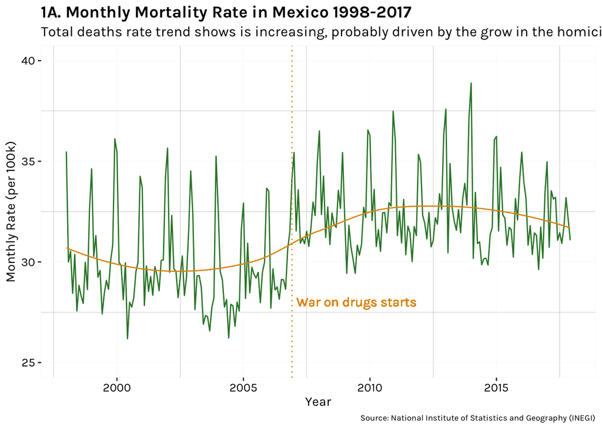

### B. Natural Deaths

Once we only consider natural deaths, we observe a similar behavior as the total deaths.

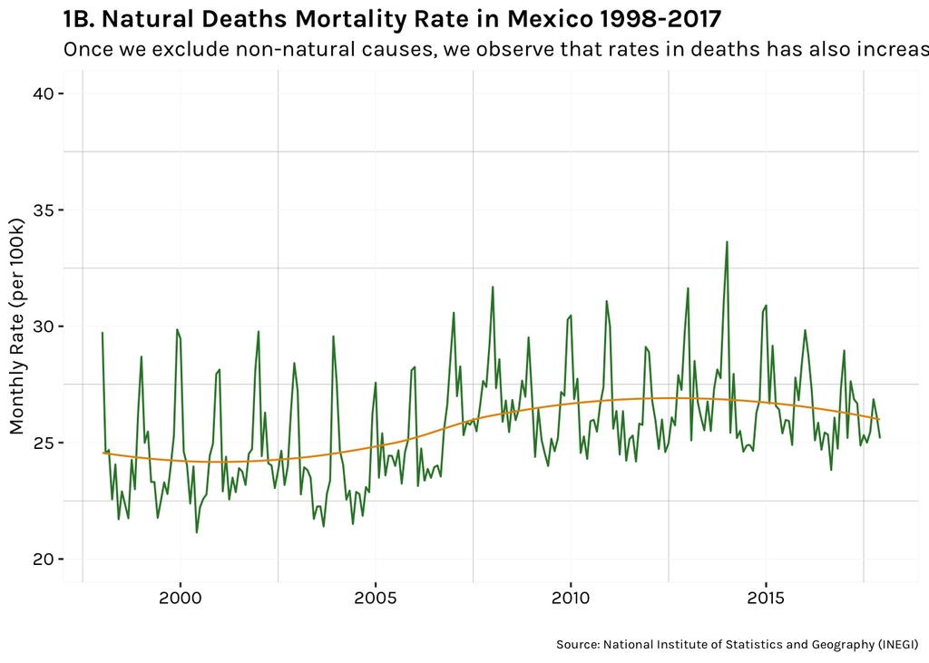

### C. Suicides

In a recent article (https://econ.st/2WuSTSN), the British magazine “The Economist” notes that the is a global trend in the decline of suicides, mostly driven by China, India and Russia. But they note that America is the big exception: this century its suicides rate has grown 18%, and if 20 years ago China’s rate double America’s, this relationship has been reversed. Perhaps for its smaller size as compared to India or China, the article does not mention Mexico, but as the chart below shows, there has been a sharp increase in suicides in the last 20 years, a period in which the rate almost doubles. Later in this work I aim to explore the data to answer some basic questions like: who are these people? where and when this phenomenon occur? and what are the characteristics of this group?

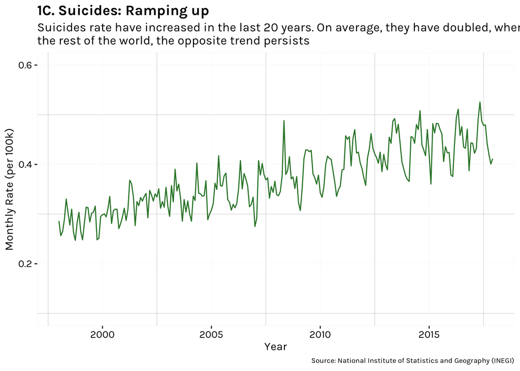

### D. Accidents

On the opposite side, we observe an important reduction in the number of people who died in an accident. The peak in the rate of deaths caused by accidents occured in December 2000, and it has remained stable since 2010.

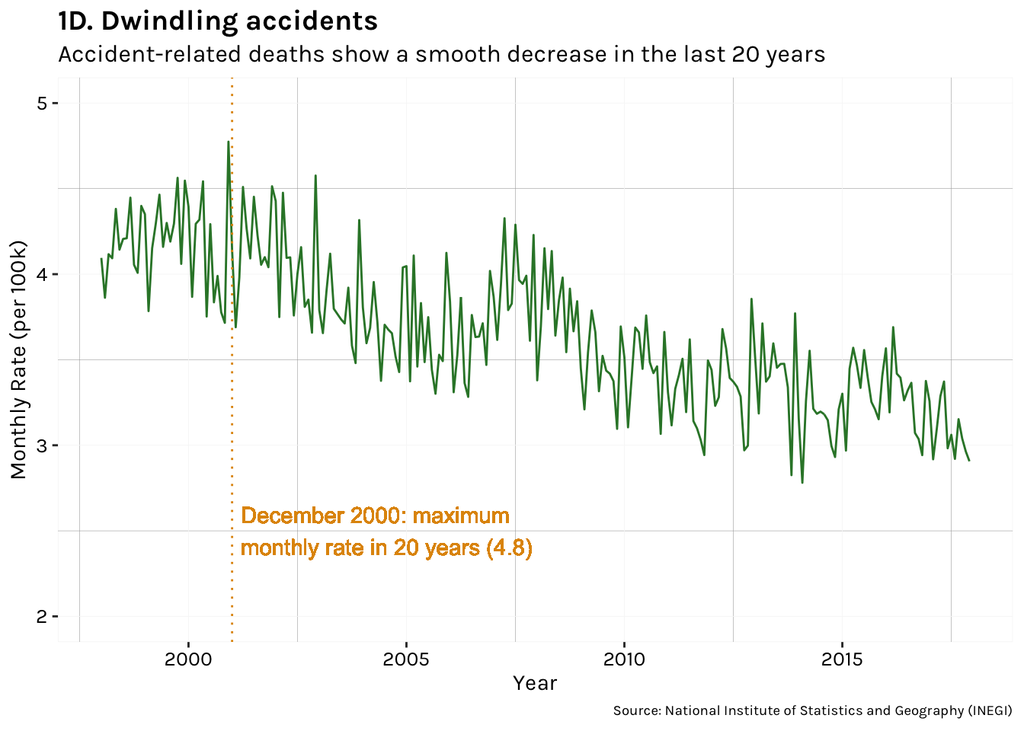

### E. Homicides

This is probably the chart that has received the most detailed analysis by scholars in Mexico in recent years. We can distinguish four periods. First, before 2006, we observe a secular decline in the rate of homicides. Using other data sources, we observe how this trend had at least 20 years of decline before 2006, and it was mostly explained because a land reform, implemented during the eighties, put an end to conflicts around land-owning disputes that usually ended with violence. Second, this declining trend ended with the implementation of the so called ‘war on drugs’, which premise was to use the military forces to dismantle drug cartels. We observe a sharp increase in homicides rate until 2011, and then a third short period in which the rate decreased. Then, after 2015, the rate increased again.

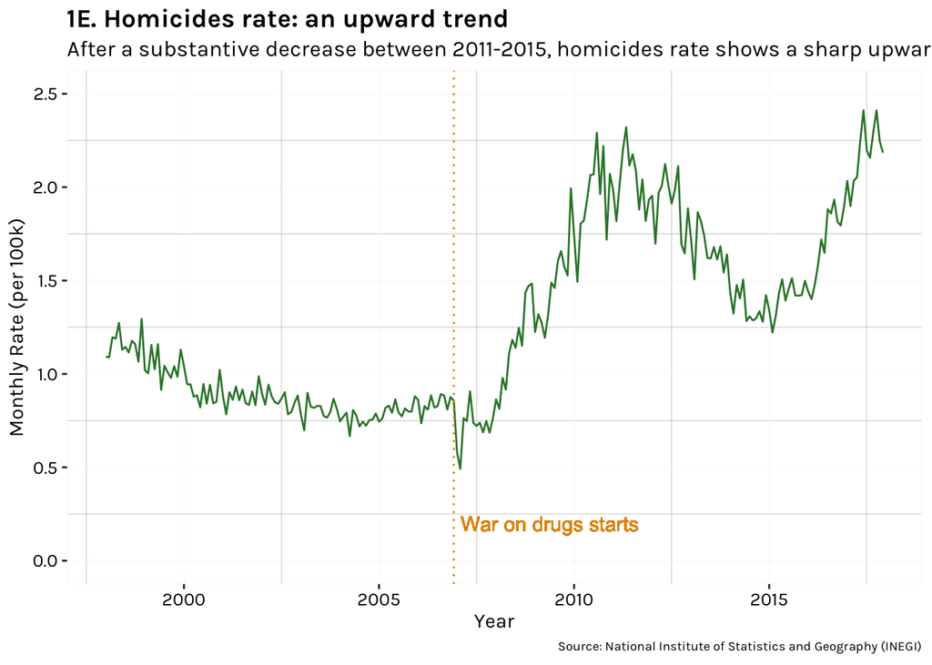

### F. War operations related deaths

This is a pretty much new classification that started to be used in the certificate deaths in 2004. We can distinguish a period between 2011 and 2015 in which both the month-to-month levels and variation in this rate increased. As the chart shows, the spikes are more frequent and of larger magnitude. Then, after this period, the spikes become shorter and the rate decreased too. I assume that these deaths are related to the army forces that lost their lives in different operations, mostly related to the fight against drug cartels. An interesting hypothesis to explore is the fact that this period of large variation also corresponds to the period of homicides decline, suggesting that a major involvement of the army forces may had a dissuasive effect on the probability of commiting homicides.

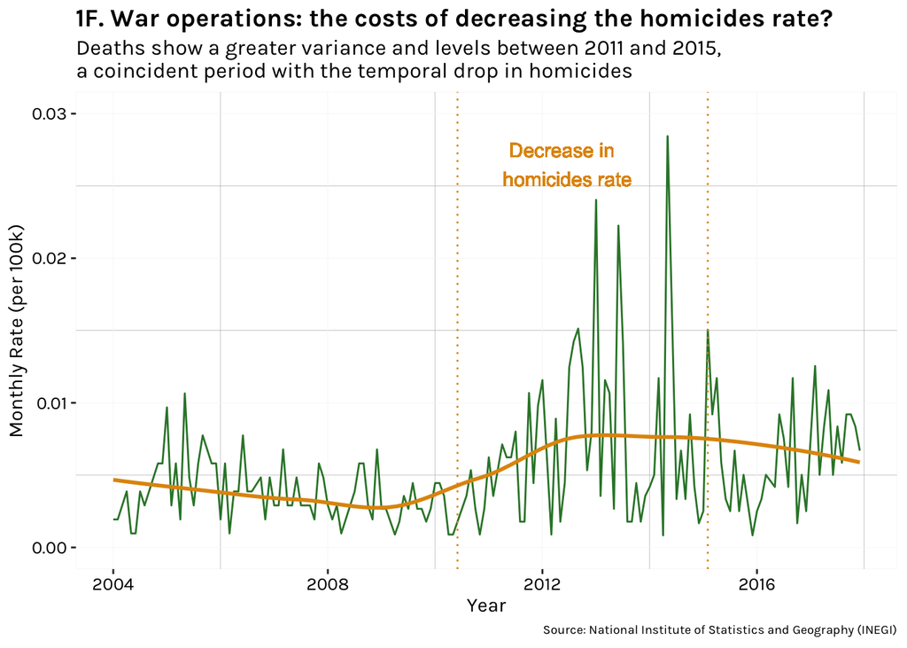

### G. Deaths with no classification

This classification correspond to non-natural casuses of death that were not classified. This chart shows an interesting behavior of deaths in this category. They follow a similar pattern as the homicides’ one: a relative decline up to the mid 2000’s; then an increase between 2010 and 2012, followed by a decrease up to around 2015. After this, we are observing an upward trend of these deaths. Finally, we should just underline that this inability to register non-natural cause deaths reflects in the best case a deterioration in the state capacity to keep the record of deaths, and in a context of the increase in violence, gives rise to doubts about the way the authorities collect and present information.

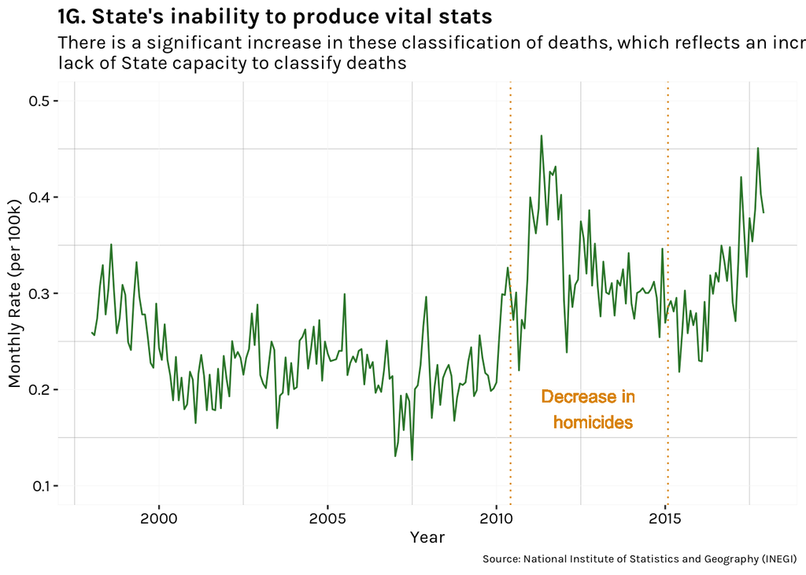

## 2. Suicides in Mexico

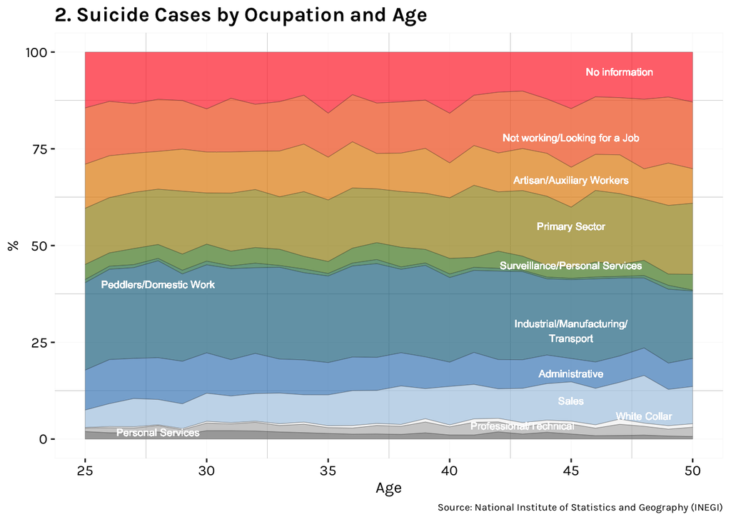

### B. Male and Female Suicides

What are the some of the characteristics of suicides in Mexico? The chart below analyzes the distribution of ages across males and females, and aims to explore if there is a change in the age composition of suicides in the last 20 years. The Economist’s article emphasizes that the drop in suicides around the world is driven by three groups: young women in China and India; middle-age men in Russia and old people all around the world. Then, a pertinent question is which groups explain the rise in suicides?

The first thing to note is that suicides are more prevalent among young and males (though with these charts I do not intend to support the argument that it is more prevalent in males). The mean age for males is around 36.1 years old, and for females is 30.5 across period 1998-2017. The chart on top shows the distribution of ages for males ([this code comes from here](https://socviz.co/refineplots.html)). From this chart, it is important to notice that across the years, the curves have flattened, suggesting that suicides are becoming more prevalent in middle-age groups (i.e. the 1998 distribution was more compact and peaked than the 2017 distribution, which left tail is getting longer, concentraring its mass distribution on the right). In fact, the average age ot death for males went from 34.6 in 1998 to 36.1, and for females from 28.9 to 31.6. This flattening of the curve is also notable for females.

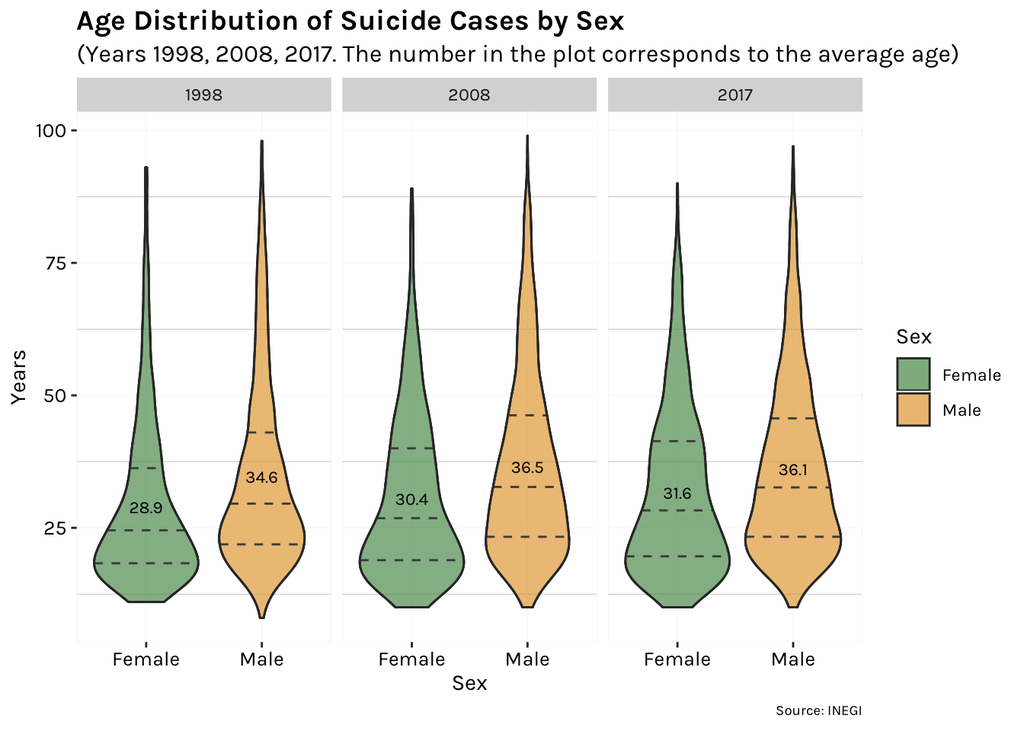

### C. Time patterns in Suicides

Differences across cohorts are remarkable. The suicides rate shows the largest increase among the young: for the 15-35 years old cohort, it increased from around 6 cases per 100k inhabitants, to a little bit more than 8 in 2017. This growth is also remarkable among the 35-50 cohort, which rose from around 5 to 7 cases per 100k. Among the 50-70 cohort we observe an relatively stable average (though it may seem to exist a seasonality pattern). Finally, in the elder cohort we see a continous drop in suicides (from around 7 to around 5 cases per 100k).

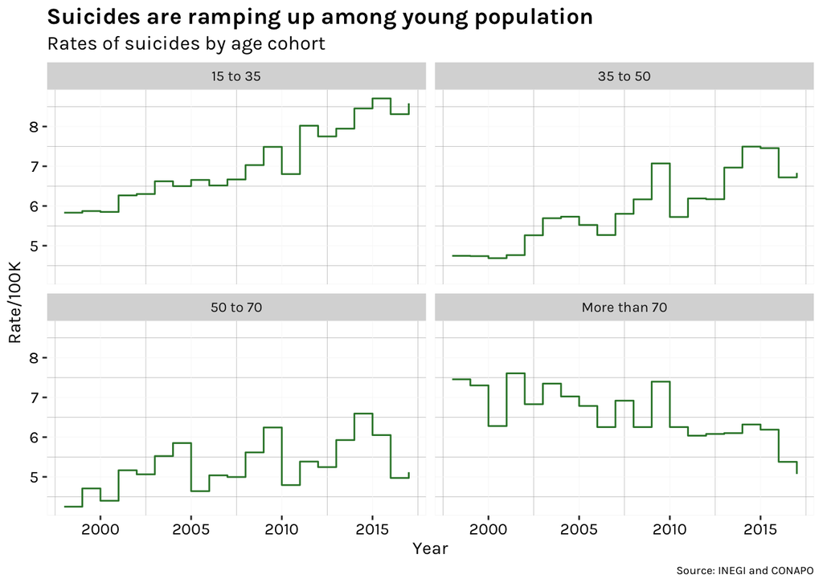

The heatmaps below analyze the temporal pattern of suicides occurence. An intervention aimed to prevent suicides should consider when suicides are more likely to occur. The heatmaps below show time patterns between male and female suicide cases. Whereas for males the likelihood of suicide occurence is greater during the weekends (the horizontal blocks for Sunday and Monday), and in any day around midnight (the vertical line on zero), these patterns do not exist in the female cases. Rather, the distribution of cases across days and times is more homogenous.[^1]

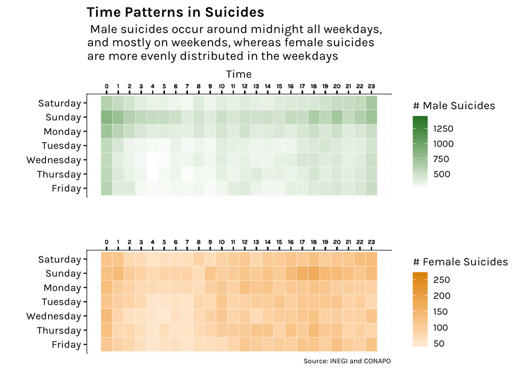

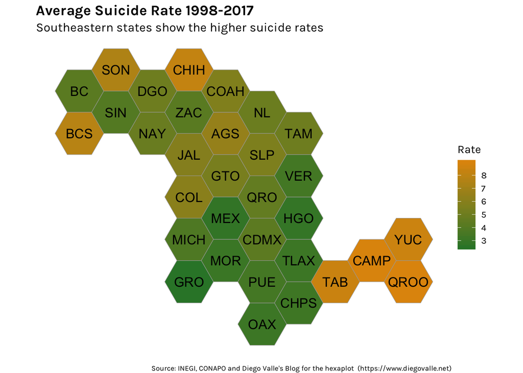

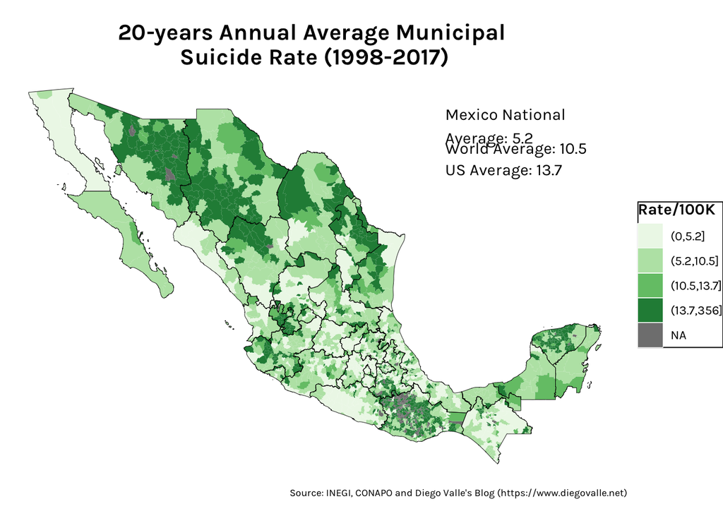

[^1]: Note that the scales are different